# Practical Machine Learning Project WriteUp

Ashok Chhilar

September 25, 2015

### Assingment Description

The goal of your project is to predict the manner in which they did the exercise. This is the “classe” variable in the training set. You may use any of the other variables to predict with. You should create a report describing how you built your model, how you used cross validation, what you think the expected out of sample error is, and why you made the choices you did.

## Reading the data

```r
library(caret);
library(rattle);
library(randomForest);
```

```r
plm.train<-read.csv(url("http://d396qusza40orc.cloudfront.net/predmachlearn/pml-training.csv"), na.strings = c("NA","#DIV/0!", ""))
plm.test<-read.csv(url("http://d396qusza40orc.cloudfront.net/predmachlearn/pml-testing.csv"), na.strings = c("NA","#DIV/0!", ""))
```

## Clean up the data

In oder to clean up the data, i remove all the columns that have 80% or more ‘NA’ values in it As the model will be trained using the clean up clumnlist, i filter the test set using those column names

```r
rows<-nrow(plm.train)
plm.train <- plm.train[!(colSums(is.na(plm.train)) > (rows*0.8))]
plm.train <- plm.train[-c(1:7)]
columns<-names(plm.train)
columns<-columns[columns!='classe']
plm.test<-plm.test[,columns]
```

# Model Training and Error estimation

Lets Split the available traning set into in.training and in.testing sets we will train the model on in.training set and estimate error using in.testing set.

```r
inTrain <- createDataPartition(y=plm.train$classe, p=0.7, list=FALSE)
in.training <- plm.train[inTrain,]
in.testing <- plm.train[-inTrain,]
dim(in.training)
```

```
## [1] 13737    53
```

```r
dim(in.testing)
```

```
## [1] 5885   53
```

# Training Using Rpart

Using Classification Trees - rpart

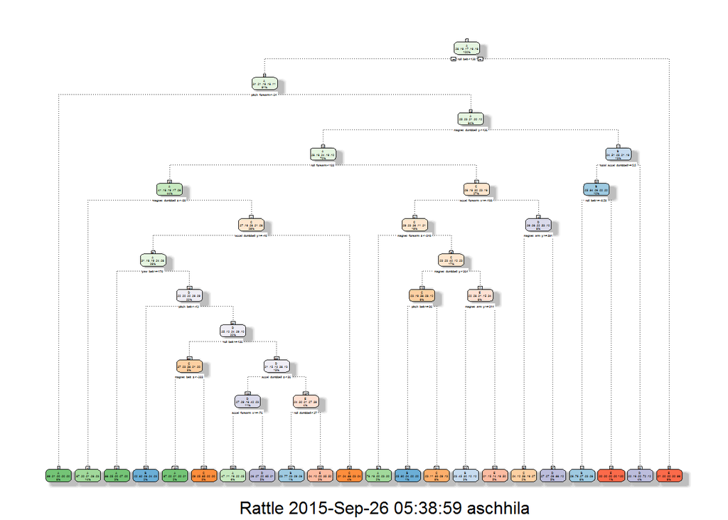

```r
set.seed(123765)
modelfit<-rpart(classe ~., method = "class", data=in.training)
fancyRpartPlot(modelfit)
```

## Estimating out of Sample Error Rate

We will use the in.testing set (which is not part of the training set) to cross validate the model and generate the error rate.

```r
predictions <- predict(modelfit, newdata=in.testing, type="class")
confusionMatrix(predictions, in.testing$classe)
```

```
## Confusion Matrix and Statistics
##
##           Reference
## Prediction    A    B    C    D    E
##          A 1562  257   62  148   50
##          B   32  655  105   43   82
##          C   29   93  736   78   80
##          D   38   74   86  583   63
##          E   13   60   37  112  807
##
## Overall Statistics
##
##                Accuracy : 0.738
##                  95% CI : (0.7265, 0.7492)
##     No Information Rate : 0.2845
##     P-Value [Acc > NIR] : < 2.2e-16
##
##                   Kappa : 0.6656
##  Mcnemar's Test P-Value : < 2.2e-16
##
## Statistics by Class:
##
##                      Class: A Class: B Class: C Class: D Class: E
## Sensitivity            0.9331   0.5751   0.7173  0.60477   0.7458
## Specificity            0.8772   0.9448   0.9424  0.94696   0.9538
## Pos Pred Value         0.7513   0.7143   0.7244  0.69076   0.7843
## Neg Pred Value         0.9706   0.9026   0.9404  0.92442   0.9434
## Prevalence             0.2845   0.1935   0.1743  0.16381   0.1839
## Detection Rate         0.2654   0.1113   0.1251  0.09907   0.1371
## Detection Prevalence   0.3533   0.1558   0.1726  0.14342   0.1749
## Balanced Accuracy      0.9052   0.7599   0.8299  0.77587   0.8498
```

# Using RandomForest

```r
set.seed(32345)
modelfit<-randomForest(classe ~., method = "class", data=in.training)
modelfit
```

```
##
## Call:
##  randomForest(formula = classe ~ ., data = in.training, method = "class")
##                Type of random forest: classification
##                      Number of trees: 500
## No. of variables tried at each split: 7
##
##         OOB estimate of  error rate: 0.58%
## Confusion matrix:
##      A    B    C    D    E class.error
## A 3901    3    1    1    0 0.001280082
## B   14 2635    9    0    0 0.008653123
## C    0   12 2381    3    0 0.006260434
## D    0    0   28 2223    1 0.012877442
## E    0    0    1    6 2518 0.002772277
```

## Estimating out of Sample Error Rate

We will use the in.testing set (which is not part of the training set) to cross validate the model and generate the error rate.

```r
predictions <- predict(modelfit, newdata=in.testing, type="class")
confusionMatrix(predictions, in.testing$classe)
```

```
## Confusion Matrix and Statistics
##
##           Reference
## Prediction    A    B    C    D    E
##          A 1672    6    0    0    0
##          B    1 1132    0    0    0
##          C    0    1 1026   12    0
##          D    0    0    0  951    3
##          E    1    0    0    1 1079
##
## Overall Statistics
##
##                Accuracy : 0.9958
##                  95% CI : (0.9937, 0.9972)
##     No Information Rate : 0.2845
##     P-Value [Acc > NIR] : < 2.2e-16
##
##                   Kappa : 0.9946
##  Mcnemar's Test P-Value : NA
##
## Statistics by Class:
##
##                      Class: A Class: B Class: C Class: D Class: E
## Sensitivity            0.9988   0.9939   1.0000   0.9865   0.9972
## Specificity            0.9986   0.9998   0.9973   0.9994   0.9996
## Pos Pred Value         0.9964   0.9991   0.9875   0.9969   0.9981
## Neg Pred Value         0.9995   0.9985   1.0000   0.9974   0.9994
## Prevalence             0.2845   0.1935   0.1743   0.1638   0.1839
## Detection Rate         0.2841   0.1924   0.1743   0.1616   0.1833
## Detection Prevalence   0.2851   0.1925   0.1766   0.1621   0.1837
## Balanced Accuracy      0.9987   0.9968   0.9987   0.9930   0.9984
```

# Conclusions

RandomForest provides better out of sample accuray than rpart, so we will use this model for further prediction.